# Automatic Parallel Coordinates Axes Sorting for Binary Classification

## by Luke Plewa - June 11th, 2015

```python
%matplotlib inline
from data_vis import load, run
```

# Introduction

In binary classification, we're interested in using a set of features to divide each sample in a dataset into one of two classes.

Parallel coordinates can help visualize this problem. The goal here is to identify multiple features which we can clump together to create a particularly accurate division. In this way, we can remove unhelpful features and only include helpful features.

This project uses a dataset of heart rates. The normal sinus rhythm (healthy) heart rates are shown in blue. The onset of sudden cardiac arrest (unhealthy) heart rates are shown in red. The dataset features almost 300 samples and has 10 derived features stored in Python pickle files. All the features are normalized beforehand.

### Binary Classification

- Machine learning problem
- Two sets of classes (healthy and unhealthy heart rates)
- Dataset = set of heart rate (HRV) derived features and class labels
- Divide each sample into one of two classes

### Parallel Coordinates

- Previous work in clustering to derive these classes, but no work where the labels are already given
- Visualize binary classification problem
- Each axis represents a heart rate derived feature
- Cluster the two classes together and as far away apart as possible
- Visualize helpful and unhelpful features

### Examples

- Red = onset of sudden cardiac arrest (unhealthy) heart rates
- Blue = normal sinus rhythm (healthy) heart rates
- 300 samples
- 10 heart rate variability features
- sample features stored in python pickle files for fast loading
- features are normalized beforehand

```python
load()
```

# Contributions

The main complaint with parallel coordinates is the big effect the sorting of the axes has on the graph. Using this complaint, this project provides the following contributions:

# The Scoring Algorithm

### Background

- Take the average of each feature for both classes
- Each subplot (the area between two axes) is represented by a trapezoid between these average features
- Scoring algorithm is modeled after the area of a trapezoid, because we want to maximize the area between these two classes
- Area of a trapezoid = (height_a + height_b) / 2.0 * base

### Implementation

For every subplot:

- Let height_a be the difference of the average features between both classes on the left feature.
- Let height_b be the difference of the average features between both classes on the right feature.
- score += abs(height_a * height_b)

For any given graph, we want the highest score possible.

```
['std_dev', 'min', 'mean', 'sdsd', 'median', 'rmsdd', 'max', 'outlier', 'nn_50', 'sdhr']
score: 0.22249022561954082
```

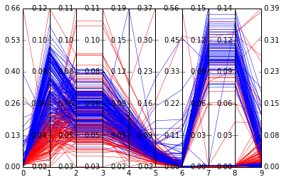

```python
# sorts the parallel coordinates in increasing order based on the average SCD class normalized feature values
run("scd")
```

```
['sdhr', 'nn_50', 'outlier', 'max', 'min', 'median', 'sdsd', 'mean', 'rmsdd', 'std_dev']
score: 0.18245909806126992
```

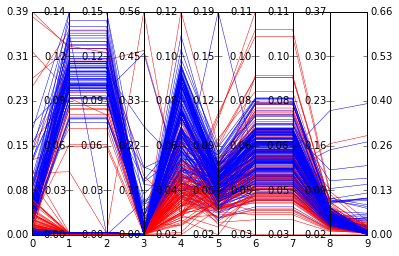

```python
# Absolute sorts the deltas by absolute value,
# giving us the features in order of highest to lowest difference by average

run("absolute")
```

```
['std_dev', 'min', 'median', 'sdsd', 'mean', 'rmsdd', 'max', 'outlier', 'nn_50', 'sdhr']
score: 0.17508011502406648
```

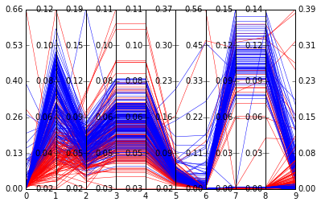

```python
# sorts the parallel coordinates in increasing order based on the average normal sinus rhythm class normalized feature values
run("norm")
```

```
['sdhr', 'std_dev', 'rmsdd', 'sdsd', 'mean', 'median', 'min', 'max', 'outlier', 'nn_50']
score: 0.1046859827814546
```

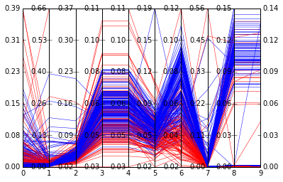

```python
# normal gives us the sorting by delta averages,
# starting with red on bottom and ending up with blue on top
run("normal")
```

# Results

```
['nn_50', 'max', 'sdhr', 'sdsd', 'min', 'outlier', 'median', 'rmsdd', 'std_dev', 'mean']
error: 0.1757012441236637
```

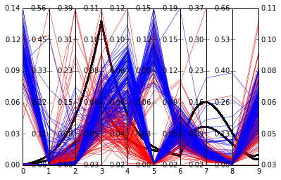

```
['std_dev', 'sdsd', 'median', 'nn_50', 'mean', 'rmsdd', 'max', 'sdhr', 'min', 'outlier']
error: 0.20959513422663908
```

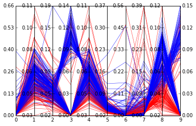

```
['median', 'mean', 'outlier', 'sdhr', 'rmsdd', 'nn_50', 'std_dev', 'max', 'min', 'sdsd']
error: 0.17808626566417704
```

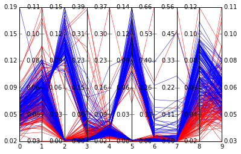

```
['sdhr', 'sdsd', 'rmsdd', 'nn_50', 'max', 'outlier', 'mean', 'min', 'median', 'std_dev']
error: 0.2199287998665183
```

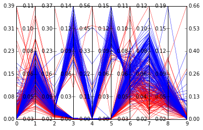

```python
# Randomly sort the axes
run(spline=True)
run()
run()
run()
```

```
['max', 'median', 'sdhr', 'mean', 'nn_50', 'std_dev', 'sdsd', 'min', 'outlier', 'rmsdd']
error: 0.15537826113197323
```

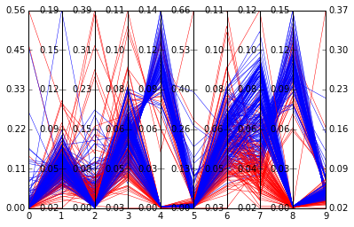

```
['outlier', 'std_dev', 'sdsd', 'nn_50', 'max', 'mean', 'rmsdd', 'min', 'sdhr', 'median']
error: 0.05961839227164985
```

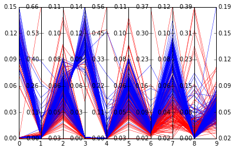

```
['sdsd', 'outlier', 'sdhr', 'median', 'rmsdd', 'nn_50', 'std_dev', 'min', 'max', 'mean']
error: 0.05510635864324331
```

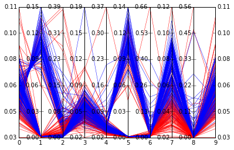

```
['rmsdd', 'std_dev', 'nn_50', 'median', 'min', 'sdhr', 'max', 'mean', 'outlier', 'sdsd']
error: 0.1864923946557482
```

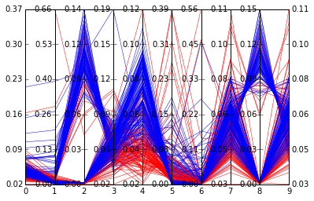

```python
run()
run()
run()
run()
```

# Works Cited

Heinrich and Weiskopf. “State of the Art of Parallel Coordinates.” 2013. University of Stuttgart. https://classes.soe.ucsc.edu/cmps261/Fall13/papers/hcmarsh/StateXofXtheXArtXofXParallelXCoordinates.pdf

Liang Fu Lu ; "A New Axes Re-ordering Method in Parallel Coordinates Visualization." Sch. of Software, Univ. of Technol., Sydney, NSW, Australia ; Mao Lin Huang ; Tze-Haw Huang http://ieeexplore.ieee.org/xpl/login.jsp?tp=&arnumber=6406759&url=http%3A%2F%2Fieeexplore.ieee.org%2Fxpls%2Fabs_all.jsp%3Farnumber%3D6406759

Makwana, Tanwani, and Jain. "Axes Re-ordering in Parallel Coordinate for Pattern Optimization." Institute of Engineering & Technology Devi Ahilya University Indore, India. 2012. http://citeseerx.ist.psu.edu/viewdoc/download?doi=10.1.1.259.2315&rep=rep1&type=pdf

Hong Zhou, Xiaoru Yuan, Huamin Qu, Weiwei Cui, Baoquan Chen. "Visual Clustering in Parallel Coordinates." Computer Science & Engineering Department, The Hong Kong University of Science and Technology, Hong Kong. 2008. http://www.cse.ust.hk/~huamin/eurovis08_zhou.pdf

# Related Works

- https://syntagmatic.github.io/parallel-coordinates/
- https://eagereyes.org/techniques/parallel-coordinates
- http://bl.ocks.org/jasondavies/1341281